# Final-Optimal-Modeling-2

## Project Apparel Price Optimization

Objective: The main idea behind this problem is the following question: As manager of a company/store, how much should I charge in order to maximize my revenue or profit? Obviously, the answer isn’t as high as possible. If you charge one hundred dollars, probably only one or two people will accept to buy it. Although the profit per product is very high, you probably won’t even your fixed costs. Charge a very small is also not the best call.

Let's start

```python
import os
import warnings
import pandas                as pd
import numpy                 as np
import seaborn               as sns
import matplotlib.pyplot     as plt
import pydotplus             as  py
import statsmodels.api       as sm
from pandas.tseries.holiday  import USFederalHolidayCalendar as calendar
from sklearn.model_selection import train_test_split
from  sklearn.tree           import DecisionTreeRegressor, export_graphviz
from sklearn.ensemble        import RandomForestRegressor, AdaBoostRegressor, GradientBoostingRegressor
from sklearn.metrics         import mean_absolute_error, mean_squared_error, r2_score
from   IPython.display       import Image as tree_image
warnings.filterwarnings('ignore')
from sklearn.metrics import accuracy_score, confusion_matrix
from sklearn.metrics import roc_curve,auc
```

Reading the filtered dataset after feature extraction

```python
df_merge     = pd.read_csv("optimization_modelingdata_full.csv")
```

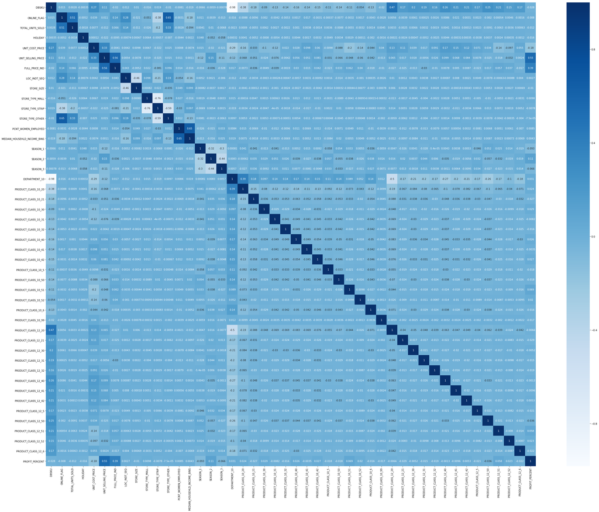

```python
# Identify feature importance - run a correlation matrix:
plt.figure(figsize=(45,35))
sns.heatmap(df_merge.corr(),cmap='Blues',annot=True)
```

List all the columns in the datafile

```python
df_merge.columns
```

```
Index(['DBSKU', 'ONLINE_FLAG', 'TOTAL_UNITS_SOLD', 'HOLIDAY',
       'UNIT_COST_PRICE', 'UNIT_SELLING_PRICE', 'FULL_PRICE_IND',
       'LOC_INDT_SEQ', 'STORE_SIZE', 'STORE_TYPE_MALL', 'STORE_TYPE_STRIP',
       'STORE_TYPE_OTHER', 'PCNT_WOMEN_EMPLOYED',
       'MEDIAN_HOUSEHLD_INCOME_BINS', 'SEASON_1', 'SEASON_2', 'SEASON_3',
       'DEPARTMENT_10', 'PRODUCT_CLASS_10_20', 'PRODUCT_CLASS_10_21',
       'PRODUCT_CLASS_10_30', 'PRODUCT_CLASS_10_31', 'PRODUCT_CLASS_10_32',
       'PRODUCT_CLASS_10_40', 'PRODUCT_CLASS_10_41', 'PRODUCT_CLASS_10_42',
       'PRODUCT_CLASS_10_5', 'PRODUCT_CLASS_10_50', 'PRODUCT_CLASS_10_51',
       'PRODUCT_CLASS_10_52', 'PRODUCT_CLASS_10_6', 'PRODUCT_CLASS_10_99',
       'PRODUCT_CLASS_12_20', 'PRODUCT_CLASS_12_21', 'PRODUCT_CLASS_12_30',
       'PRODUCT_CLASS_12_31', 'PRODUCT_CLASS_12_32', 'PRODUCT_CLASS_12_40',
       'PRODUCT_CLASS_12_41', 'PRODUCT_CLASS_12_42', 'PRODUCT_CLASS_12_5',
       'PRODUCT_CLASS_12_50', 'PRODUCT_CLASS_12_51', 'PRODUCT_CLASS_12_52',
       'PRODUCT_CLASS_12_6', 'PROFIT_PERCENT'],
      dtype='object')
```

Listing the top 5 lines of the datafile

```python
df_merge.head()
```

|  | DBSKU | ONLINE_FLAG | TOTAL_UNITS_SOLD | HOLIDAY | UNIT_COST_PRICE | UNIT_SELLING_PRICE | FULL_PRICE_IND | LOC_INDT_SEQ | STORE_SIZE | STORE_TYPE_MALL | ... | PRODUCT_CLASS_12_32 | PRODUCT_CLASS_12_40 | PRODUCT_CLASS_12_41 | PRODUCT_CLASS_12_42 | PRODUCT_CLASS_12_5 | PRODUCT_CLASS_12_50 | PRODUCT_CLASS_12_51 | PRODUCT_CLASS_12_52 | PRODUCT_CLASS_12_6 | PROFIT_PERCENT |
| --- | --- | --- | --- | --- | --- | --- | --- | --- | --- | --- | --- | --- | --- | --- | --- | --- | --- | --- | --- | --- | --- |
| 0 | 466896 | 0 | 1.0 | 0 | 15.5 | 16.80 | 0 | 1027 | 3100 | 0 | ... | 0 | 0 | 0 | 0 | 0 | 0 | 0 | 0 | 0 | 8.387097 |
| 1 | 466896 | 0 | 2.0 | 0 | 15.5 | 16.80 | 0 | 1027 | 3100 | 0 | ... | 0 | 0 | 0 | 0 | 0 | 0 | 0 | 0 | 0 | 8.387097 |
| 2 | 466896 | 0 | 1.0 | 0 | 15.5 | 21.00 | 0 | 1027 | 3100 | 0 | ... | 0 | 0 | 0 | 0 | 0 | 0 | 0 | 0 | 0 | 35.483871 |
| 3 | 466896 | 0 | 1.0 | 0 | 15.5 | 14.70 | 0 | 1027 | 3100 | 0 | ... | 0 | 0 | 0 | 0 | 0 | 0 | 0 | 0 | 0 | -5.161290 |
| 4 | 412445 | 0 | 1.0 | 0 | 17.0 | 29.99 | 0 | 1027 | 3100 | 0 | ... | 0 | 0 | 0 | 0 | 0 | 0 | 0 | 0 | 0 | 76.411765 |

5 rows × 46 columns

Profit percent in percentage wise

```python
round(df_merge.PROFIT_PERCENT.describe([0.1,0.2,0.3,0.4,0.6,0.7,0.8,0.9,0.999]),1)
```

```
count    13043875.0
mean          118.9
std           111.2
min          -100.0
10%             9.5
20%            40.8
30%            79.0
40%           109.1
50%           126.7
60%           145.4
70%           166.7
80%           182.9
90%           208.5
99.9%         348.0
max        189800.0
Name: PROFIT_PERCENT, dtype: float64
```

```python
df_merge=df_merge[df_merge['PROFIT_PERCENT'] > 40.8]
```

removing outliers (Too overprofitted transactions). Here cutoff limit is 99.9th percentile

```python
df_merge = df_merge[(df_merge['PROFIT_PERCENT'] <= 348.0)]
```

Drop the profit percent and Loc ID column from the datafile

```python
df_merge.drop(['PROFIT_PERCENT','LOC_INDT_SEQ'], axis=1,inplace=True)
df_merge.shape
```

```
(10421752, 44)
```

```python
df_merge.dtypes
```

```
DBSKU                            int64
ONLINE_FLAG                      int64
TOTAL_UNITS_SOLD               float64
HOLIDAY                          int64
UNIT_COST_PRICE                float64
UNIT_SELLING_PRICE             float64
FULL_PRICE_IND                   int64
STORE_SIZE                       int64
STORE_TYPE_MALL                  int64
STORE_TYPE_STRIP                 int64
STORE_TYPE_OTHER                 int64
PCNT_WOMEN_EMPLOYED            float64
MEDIAN_HOUSEHLD_INCOME_BINS      int64
SEASON_1                         int64
SEASON_2                         int64
SEASON_3                         int64
DEPARTMENT_10                    int64
PRODUCT_CLASS_10_20              int64
PRODUCT_CLASS_10_21              int64
PRODUCT_CLASS_10_30              int64
PRODUCT_CLASS_10_31              int64
PRODUCT_CLASS_10_32              int64
PRODUCT_CLASS_10_40              int64
PRODUCT_CLASS_10_41              int64
PRODUCT_CLASS_10_42              int64
PRODUCT_CLASS_10_5               int64
PRODUCT_CLASS_10_50              int64
PRODUCT_CLASS_10_51              int64
PRODUCT_CLASS_10_52              int64
PRODUCT_CLASS_10_6               int64
PRODUCT_CLASS_10_99              int64
PRODUCT_CLASS_12_20              int64
PRODUCT_CLASS_12_21              int64
PRODUCT_CLASS_12_30              int64
PRODUCT_CLASS_12_31              int64
PRODUCT_CLASS_12_32              int64
PRODUCT_CLASS_12_40              int64
PRODUCT_CLASS_12_41              int64
PRODUCT_CLASS_12_42              int64
PRODUCT_CLASS_12_5               int64
PRODUCT_CLASS_12_50              int64
PRODUCT_CLASS_12_51              int64
PRODUCT_CLASS_12_52              int64
PRODUCT_CLASS_12_6               int64
dtype: object
```